# Exercises for MedCof7 RTC Practical Training 2016 - Group A

# Conditional statements

### Chunk 1 (if statement)

```r
z = 1 + 2i
z
```

```
## [1] 1+2i
```

```r
if (is.complex(z)==TRUE){print("z is complex")}
```

```
## [1] "z is complex"
```

### Chunk 2 (if-else statement)

```r
if (is.integer(z) == TRUE){
    print("z is complex")
}else{
    paste("z is",typeof(z))   # paste() combine objects and strings
  }
```

```
## [1] "z is complex"
```

### Exercise 1

Install and load `{latticeExtra}` package that contains a variety of datasets. For a complete list, use > library(help = “latticeExtra”)

and print the `EastAuClimate` one, which contains Climate of the East Coast of Australia.

If `EastAuClimate` is a data.frame object, then extract `SummerMaxTemp` from it. If there are more than 10 data, then make a scatter plot.

Solution:

```r
library(latticeExtra)
library(help = "latticeExtra")
str(EastAuClimate)
```

```
## 'data.frame':    16 obs. of  15 variables:
##  $ SummerMaxTemp: num  22 20.9 21.5 26.5 20.7 24 23.4 26.7 26.2 27.4 ...
##  $ SummerMinTemp: num  12.7 14.4 14.3 15.8 15.3 14.8 16.4 19.3 19.2 20.6 ...
##  $ WinterMaxTemp: num  12.2 13 12.9 13.9 12.3 14.7 16.1 17 18.2 19.4 ...
##  $ WinterMinTemp: num  4.7 7 7.7 6.8 8.8 5.8 6.6 7.4 7.9 11.7 ...
##  $ SummerRain   : num  28.1 30.8 32 32.3 33.8 ...
##  $ WinterRain   : num  44.1 78.4 107.3 46.8 125.2 ...
##  $ MeanAnnRain  : num  576 757 952 654 1109 ...
##  $ RainDays     : num  90.8 103.2 141 99.2 137.1 ...
##  $ ClearDays    : num  41.1 46 25.3 48.9 22.3 ...
##  $ CloudyDays   : num  177 140 221 178 218 ...
##  $ ID           : int  94029 92045 90015 86071 85096 84083 69022 66037 60026 58009 ...
##  $ Latitude     : num  -42.9 -41 -38.9 -37.8 -39.1 ...
##  $ Longitude    : num  147 148 144 145 146 ...
##  $ Elevation    : int  51 82 82 31 95 43 25 6 20 95 ...
##  $ State        : Factor w/ 4 levels "NSW","QLD","TAS",..: 3 3 4 4 4 4 1 1 1 1 ...
```

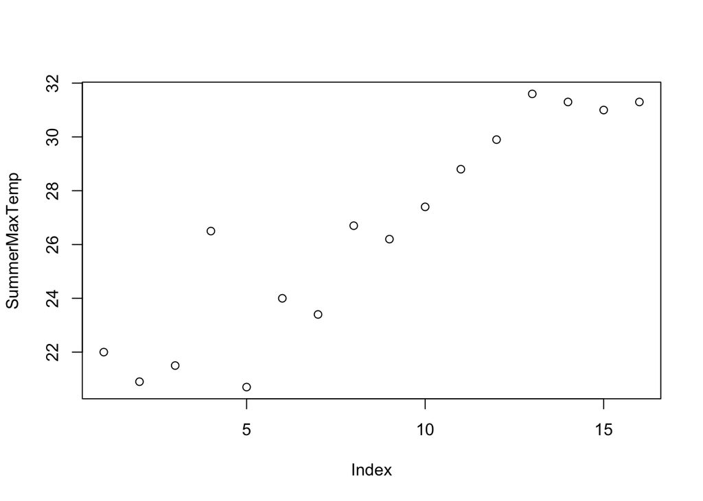

```r
if(class(EastAuClimate)=="data.frame"){
  SummerMaxTemp<-EastAuClimate$SummerMaxTemp
  if(length(SummerMaxTemp)>10){plot(SummerMaxTemp)}
}
```

# Data Import from Excel

### Clipboard

Notice that you need to specify some arguments of the `read.table()` function accordingly with the characteristics of the file to be imported:

- `sep` is the field separator character;
- `dec` the character used in the file for decimal points;
- `header` a logical value indicating whether the file contains the names of the variables as its first line;
- …

### Read data directly from file

Obviously, the “clipboard” method is unefficient when you need to read multiple files. However, there are several ways to read Excel files. Here, we use the function `read.xls()` in `{gdata}` package

### Exercise 2

1. Install `{gdata}`, `{Hmisc}`, `{maps}` and `{ggplot2}` packages
2. Import and print data from file `Data/SeasFor_GCM_NCEP_datafile.xlsx`

```r
library(gdata)
Ncep <- read.xls("Data/SeasFor_GCM_Ncep_datafile.xlsx")

str(Ncep)
```

```
## 'data.frame':    497 obs. of  3 variables:
##  $ L                 : num  0.5 1.5 2.5 3.5 4.5 5.5 6.5 0.5 1.5 2.5 ...
##  $ Forecast.Started  : Factor w/ 71 levels "1998-07-01T00:00",..: 1 1 1 1 1 1 1 2 2 2 ...
##  $ precipitation.rate: num  0.82 0.511 1.343 2.074 3.142 ...
```

```r
summary(Ncep)
```

```
##        L               Forecast.Started precipitation.rate
##  Min.   :0.5   1998-07-01T00:00:  7     Min.   :0.511
##  1st Qu.:1.5   1998-08-01T00:00:  7     1st Qu.:1.238
##  Median :3.5   1998-09-01T00:00:  7     Median :2.074
##  Mean   :3.5   1998-10-01T00:00:  7     Mean   :2.077
##  3rd Qu.:5.5   1998-11-01T00:00:  7     3rd Qu.:2.826
##  Max.   :6.5   1998-12-01T00:00:  7     Max.   :4.487
##                (Other)         :455     NA's   :50
```

3. Transform data of `$Forecast.Started` column in date format and extract the number of days from each forecasted month

```r
Ncep$Forecast.Started<-as.Date(Ncep$Forecast.Started,format="%Y-%m-%dT%H:%M")
head(Ncep)
```

```
##     L Forecast.Started precipitation.rate
## 1 0.5       1998-07-01          0.8201456
## 2 1.5       1998-07-01          0.5109688
## 3 2.5       1998-07-01          1.3429490
## 4 3.5       1998-07-01          2.0742040
## 5 4.5       1998-07-01          3.1423840
## 6 5.5       1998-07-01          3.3625960
```

```r
library(Hmisc)   # for monthDays()
Forecast.Days0<-monthDays(Ncep$Forecast.Started)
```

4. Calculate the cumulated precipitation starting from data in `$precipitation.rate` column (precipitation rate unity measure is *mm/day*)

```r
Ncep$Forecast.Days<-Forecast.Days0*Ncep$L
Ncep$Forecast.Date<-Ncep$Forecast.Started+ Ncep$Forecast.Days
Ncep$ConvertDays<-monthDays(Ncep$Forecast.Date)

Ncep$Mon.Cum <- round(Ncep$precipitation.rate * Ncep$ConvertDays,1)
range(Ncep$Mon.Cum,na.rm=T)    # a quick check
```

```
## [1]  15.8 139.1
```

5. Locate the cell over the world map

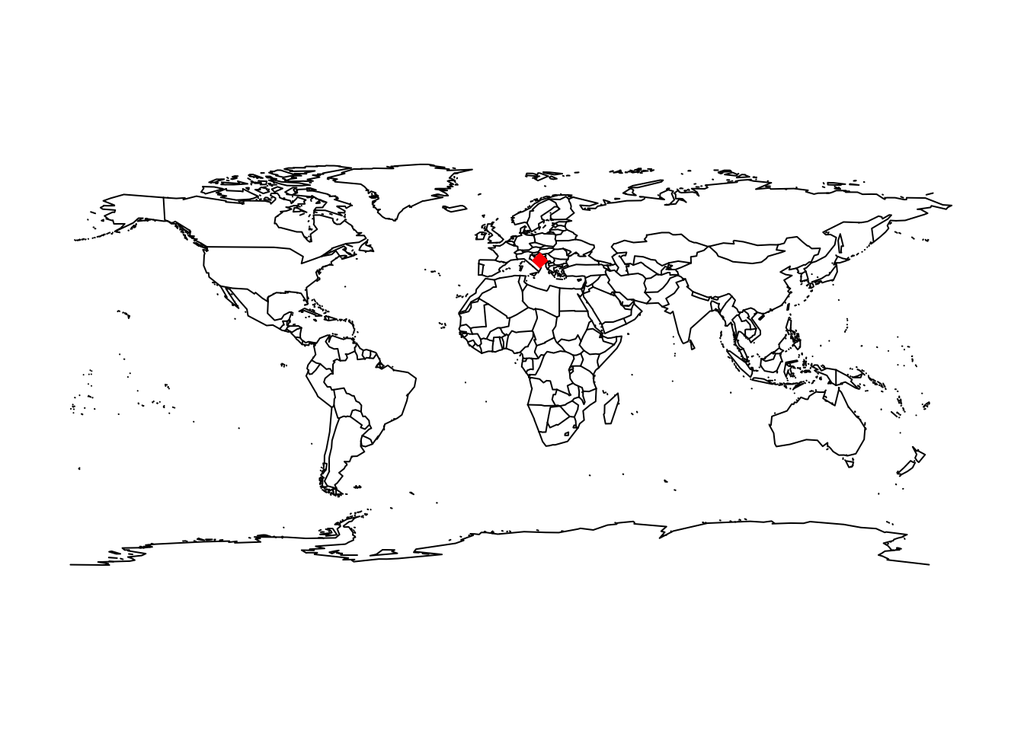

```r
require(maps)
map("world")
points(16.875, 43.2542, col="red", pch=18,cex=1.5)
```

6. Group and plot by outlooks (to do step by step with teacher)

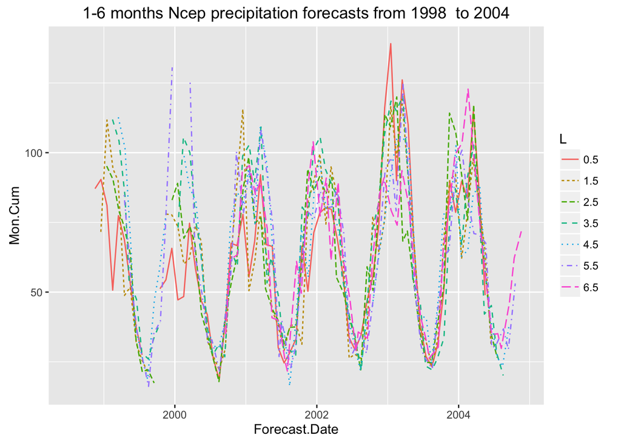

```r
library(ggplot2)

# get years  from date and select the first and the last:
Ybegin<-as.numeric(getYear(Ncep$Forecast.Date)[1])
Yend<-as.numeric(getYear(Ncep$Forecast.Date)[nrow(Ncep)] )

#transform Ncep data frame:
Ncep2<-Ncep
Ncep2$L<-as.factor(Ncep$L)    # L as factor

#Plot
p<-ggplot(Ncep2, aes(x=Forecast.Date, y=Mon.Cum,  colour=L,linetype=L)) + geom_line()
p+ ggtitle(paste("1-6 months Ncep precipitation forecasts from",Ybegin," to", Yend))
```

```r
ggsave(paste(getwd(),"/Plots/Ncep_forecasts.pdf",sep=""),
       width = 19, height = 14, units = "cm")
```

# Visualizing

### Exercise 3

Make a bubble plot (i.e. a scatter plot that represents its points as circles) with $500$ data extracted from `rnorm()` function, where the bubble size is determined by a poisson process with $\lambda=0.4$.

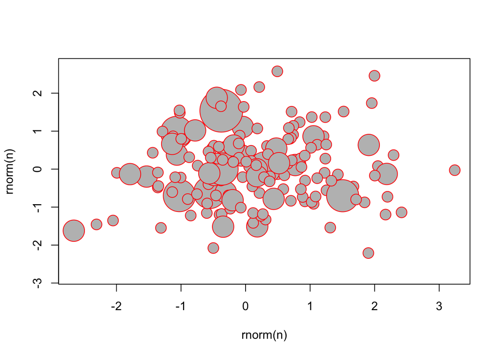

```r
n = 500
set.seed(123)     # fix the seed for number random generation
#par(mar = c(4, 4, 0.1, 0.1))
plot(rnorm(n), rnorm(n), pch = 21, cex = 2 * rpois(n,lambda = 0.4), col = "red", bg = "gray")
```

### Recommended book

1. install package `{gcookbook}` and load it, then have a look at climate object, which contains **Global climate temperature anomaly data from 1800 to 2011**;
2. follow the example below to plot data (this example is taken from [Cookbook for R] (http://www.cookbook-r.com)

```r
library(gcookbook)
library(help="gcookbook")
str(climate)
```

```
## 'data.frame':    499 obs. of  6 variables:
##  $ Source    : chr  "Berkeley" "Berkeley" "Berkeley" "Berkeley" ...
##  $ Year      : num  1800 1801 1802 1803 1804 ...
##  $ Anomaly1y : num  NA NA NA NA NA NA NA NA NA NA ...
##  $ Anomaly5y : num  NA NA NA NA NA NA NA NA NA NA ...
##  $ Anomaly10y: num  -0.435 -0.453 -0.46 -0.493 -0.536 -0.541 -0.59 -0.695 -0.763 -0.818 ...
##  $ Unc10y    : num  0.505 0.493 0.486 0.489 0.483 0.475 0.468 0.461 0.453 0.451 ...
```

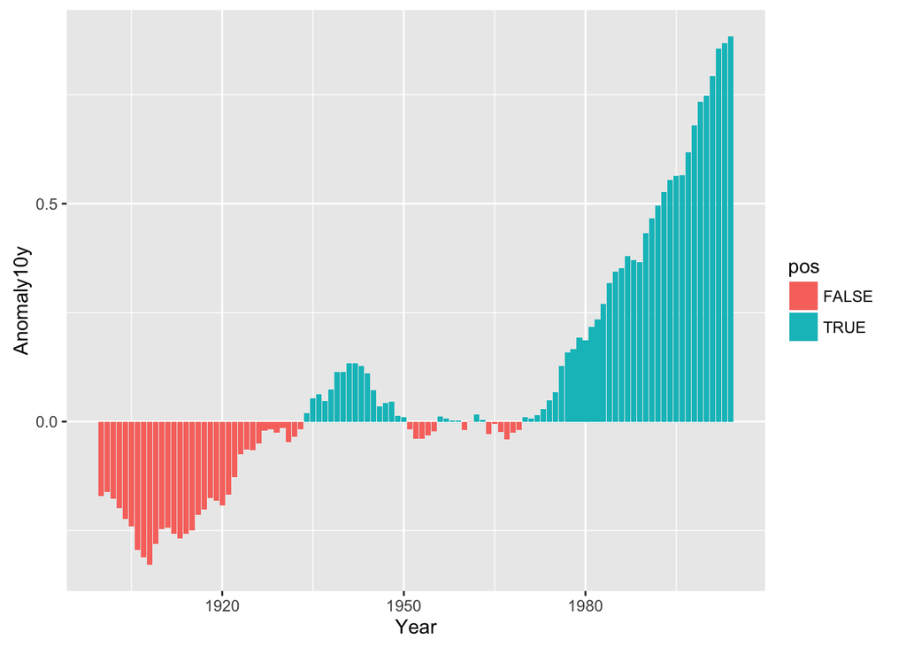

```r
csub <- subset(climate, Source=="Berkeley" & Year >= 1900)
csub$pos <- csub$Anomaly10y >= 0

ggplot(csub, aes(x=Year, y=Anomaly10y, fill=pos)) +
      geom_bar(stat="identity", position="identity")
```